# Bootstrap for testing number of model parameters.

Zeinab Mousavi

Bootstrap implementation for evaluating goodness of fit of two models.

### Description

Input $X$ are independent observed random samples drawn from an unknown population. We compare its goodness of fit under the null and alternative models:

$X$ ~ $\sum_{k=1}^{k_{max}} \pi_{k} * N(\mu_{k}, \sigma^{2})$ s.t. $\sum_{k=1}^{k_{max}} \pi_{k} = 1$

Ho: $k_{max} = k_{0}$

Ha: $k_{max} = k_{1}$

In this example, $k_{0} = 1$ and $k_{1} = 2$

### Inputs:

$x_i \in R$ for $i \in {1, ..., n}$

### Assumptions:

$\sigma^{2}$ = 1

### Outputs:

p-value for observed graph statistic, scalar

power of the test, scalar

### Function:

Evaluate parameter estimates of observed data under both models

1a. $\hat{\mu}_{0} = \frac{1}{n}{\sum_{i=1}^{n}x_i}$

1b. $\hat{\mu}_{1_{,1}}, \hat{\mu}_{1_{,2}},\hat{\pi}_{1} = argmax (L({\mu}_{1_{,1}}, {\mu}_{1_{,2}},{\pi}_{1};X))$

Compute test statistic of observed data

2. $\delta_{data} = -2 * (ln(L(k_{0}|X)) - ln(L(k_{1}|X)))$

Generate bootstrap samples and evaluate log likelihood ratio under the null model

3. for b = {1, .., B}:

Simulate

${x}^{b}_{i}$ ~ $\sum_{k=1}^{k_{0}} \pi_{k} * N(\hat{\mu}_{0}, \sigma^{2})$

Fit

$\hat{\mu}^{b}_{0} = \frac{1}{n}{\sum_{i=1}^{n}{x}^{b}_{i}}$

$\hat{\mu}^{b}_{1_{,1}}, \hat{\mu}^{b}_{1_{,2}},\hat{\pi}^{b}_{1} = argmax (L({\mu}^{b}_{1_{,1}}, {\mu}^{b}_{1_{,2}},{\pi}_{1};X))$

Evaluate

$\hat\delta^{b} = -2 * (ln(L(k_{0}|X^{b})) - ln(L(k_{1}|X^{b})))$

end

Compute p-value

4. p-value = $\frac{count(\hat\delta^{b} \geq \hat\delta_{obs})}{B}$

Find critical value for $\alpha$ = 0.05

5. $\hat\delta_{c}$ = quantile $( \hat\delta^{b}, .95)$

### Power of Test

Construct bootstrap samples under the alternative model

6. for b = {1, .., B}:

Simulate

${x}^{b}_{i}$ ~ $\sum_{k=1}^{k_{0}} \pi_{k} * N(\hat{\mu}_{1}, \sigma^{2})$

Fit

$\hat{\mu}^{b}_{0} = \frac{1}{n}{\sum_{i=1}^{n}{x}^{b}_{i}}$

$\hat{\mu}^{b}_{1_{,1}}, \hat{\mu}^{b}_{1_{,2}},\hat{\pi}^{b}_{1} = argmax (L({\mu}^{b}_{1_{,1}}, {\mu}^{b}_{1_{,2}},{\pi}_{1};X))$

Evaluate

$\hat\delta^{b} = -2 * (ln(L(k_{0}|X^{b})) - ln(L(k_{1}|X^{b})))$

end

Compute Power

9. Power = $\frac{count(\hat\delta^{b} \geq \hat\delta_{c})}{B}$

```r
require(mixtools)
require(mclust)
```

### Simulations

On dataset of size n is simulated by equally uniform sampling of two Gaussian distributions.

When the difference between the means of the two Gaussians is not zero, such as 0.5, we expect the Null Hypothesis to be rejected, p_value <0.05. We also expect the power of the test to inrease as sample size increases.

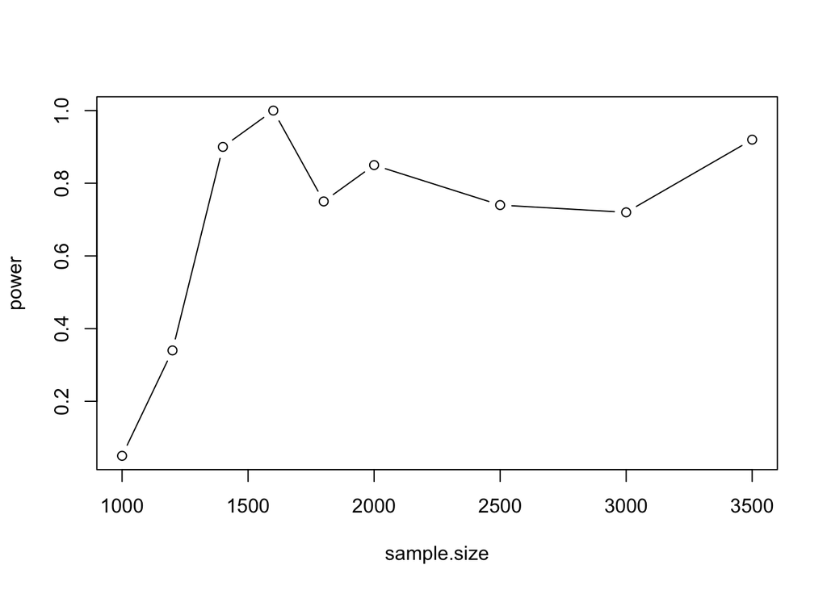

```r
sample.size = c(seq(1000, 2000, 200), seq(2500, 3500, 500))

p_value <- c()
power <- c()
k <- 0
for (n.sample in sample.size){

set.seed(1)
X.data = c(rnorm(n=n.sample, mean=0, sd =1), rnorm(n=n.sample, mean=0.5, sd =1))


data.mean.null <- mean(X.data)
data.loglik.null = sum(log(dnorm(X.data,mean=data.mean.null,sd=1)))
data.fit.alt = normalmixEM(X.data,k=2)
data.loglik.alt = data.fit.alt$loglik
data.mean.alt = data.fit.alt$mu
data.lambda.alt = data.fit.alt$lambda
data.stat = - 2 * (data.loglik.null - data.loglik.alt)


boot_strap <- 100
test.stat.null <- c()
test.stat.alt <- c()

for (b in seq(1, boot_strap)){

  X.boot.null <- rnorm(length(X.data), mean=data.mean.null, sd=1)
  loglik.null = sum(log(dnorm(X.boot.null,mean=mean(X.boot.null),sd=1)))
  loglik.alt = normalmixEM(X.boot.null,k=2)$loglik
  test.stat.null[b] = - 2 * (loglik.null - loglik.alt)
}

k <- k+1
p_value[k] = sum(data.stat<test.stat.null)/boot_strap #== 1-ecdf(test.stat.null)(data.stat)
critical.stat = quantile(test.stat.null, 0.95)[1]

print (p_value[k])

for  (b in seq(1, boot_strap)){
  X.boot.alt = rnormmix(n=n.sample, lambda=data.lambda.alt, mu=data.mean.alt, sigma=1)
  loglik.null = sum(log(dnorm(X.boot.alt,mean=mean(X.boot.alt),sd=1)))
  loglik.alt = normalmixEM(X.boot.alt,k=2)$loglik
  test.stat.alt[b] =  - 2 * (loglik.null - loglik.alt)
}

power[k]  = sum(critical.stat<test.stat.alt)/boot_strap #== 1-ecdf(test.stat.alt)(data.stat)

print (power[k])

}

plot(sample.size, power, type="b")
```